# Module 4: Project 2 by Team 5

Charting the distributed nitrogen cycle

Karl Abuan

May Ho

Wei Ting Lin (Jonah)

Leilynaz Malekafzali

Tiffany Yang

Abdur Rahman M. A. Basher

April 25, 2018

```r
## try http:// if https:// URLs are not supported
source("https://bioconductor.org/biocLite.R")
biocLite("phyloseq")
library("tidyverse")
library("gridExtra")
library("magrittr")
library("ggpubr")
library("cowplot")
```

# Introduction

Saanich Inlet, located in southeastern Vancouver Island, is a seasonally anoxic fjord and therefore an ideal model to study microbial community responses to ocean deoxygenation (1, 2). Established by the shallow sill opening to the Strait of Georgia, circulation of basin water in Saanich Inlet is reduced. Together with poor ventilation and intense downward flux of organic matter by aerobically respiring organisms living on surface waters (3), oxygen levels down the inlet water column decreases followed by changes in nutrient availability. With the lack of oxygen, microbes turn to use alternative terminal electron acceptors such as nitrate, followed by sulphate (4). Thus, these oxygen-deprived regions, termed as oxygen minimum zones (OMZs), post a diverse microbial community that mediate important biogeochemical processes such the nitrogen cycle (4). Since OMZs provide appropriate conditions to enable substantial nitrogen loss, we aim to reassemble the nitrogen cycle in Saanich Inlet as a model to study the microbial community responses to varying levels of oxygen deficiency with specific emphasis on the denitrification pathway.

**The Nitrogen Cycle**

Nitrogen is the fourth most abundant element in the cellular biomass (5). Microbial activities entirely control the interchange between the inert N<sub>2</sub> gas in the atmosphere to usable nitrogen that can support cellular metabolism and growth (5). The nitrogen cycle consists of four significant nitrogen-transformation flows: ammonification, nitrification, denitrification, anammox (5). Ammonification, includes nitrogen fixation, where N<sub>2</sub> is reduced to ammonium by bacteria and archaea that encode nitrogenase enzyme, and also the assimilatory and dissimilatory reduction of nitrate to ammonium (5). It should be noted that nitrogen fixation is an oxygen sensitive process as nitrogenase enzyme is inhibited by oxygen (6). Nitrification is the process of oxidation of ammonia to nitrite, and further oxidation of nitrite to nitrate (5). Denitrification is the process of dissimilatory reduction of nitrate (NO<sub>3</sub><sup>-</sup>) and nitrite (NO<sub>2</sub><sup>-</sup>) to the gaseous oxides, nitric oxide (NO), and nitrous oxide (N<sub>2</sub>O), which may further get reduced to dinitrogen gas (N<sub>2</sub>) (5). In anaerobic ammonium oxidation commonly abbreviated as anammox, the pools of nitrite (N<sub>2</sub>O<sup>-</sup>) and ammonium (NH<sub>4</sub><sup>+</sup>) are utilized to form N<sub>2</sub> (5). Anammox is used for wastewater treatment, as it removes both ammonium and nitrite simultaneously without producing N<sub>2</sub>O (5).

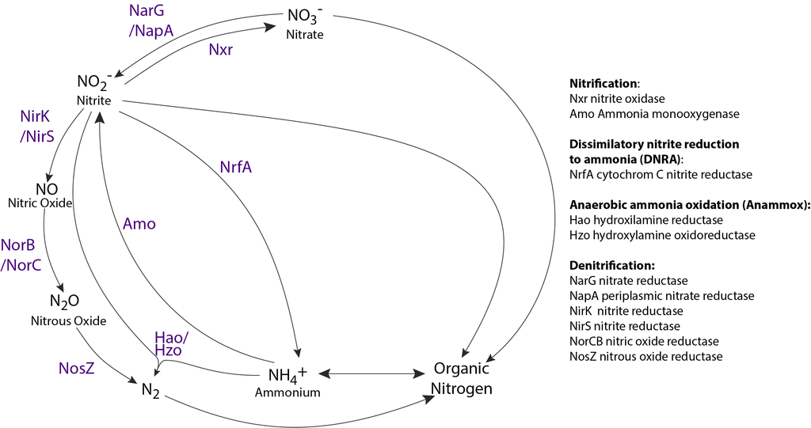

Figure 1: Nitrogen Cycle

The denitrification process plays an integral role in the global nitrogen balance. It returns the nitrogen into the atmosphere and maintains homeostasis between the nitrogen content of soil and air. (8). The four enzymes of denitrification are: nitrate, nitrite, nitric oxide and nitrous oxide reductase which are encoded by *nar*, *nir*, *nor*, and *nos*, respectively (9). Denitrification takes place in aquatic, marine, and terrestrial ecosystems, and the rate of this process is affected by various factors such as pH, temperature, and oxygen concentration (8). In OMZs, nitrate (NO<sub>3</sub><sup>-</sup>) and nitrite (NO<sub>2</sub><sup>-</sup>) act as the main terminal electron acceptors in respiration (10). Nitrogen oxide reductases are sensitive to oxygen and it is known that oxygen represses denitrification (8). Among the four N-oxide reductases, nitrous oxide reductase is the most sensitive enzyme to oxygen, leading to the increase in N<sub>2</sub>O production in the suboxic and anoxic conditions (10). The interest in denitrification process is for several reasons. Denitrification is the process contributing to the loss of fertilizer nitrogen, therefore reducing the agriculture productivity (7). Additionally, denitrification can be utilized to remove nitrogen from high-nitrate wastewaters to decrease the contamination and eutrophication (7). However, denitrification can have negative effects on the climate system, as the emission of N<sub>2</sub>O leads to stratospheric ozone layer depletion, contributing to global warming (7). Some of the major denitrifying bacteria are from genera: *Alcaligenes*, *Agrobacterium*, *Bacillus*, *Hyphomicrobium*, *Moraxella*, *Pseudomonas*, and *Paracoccus* (7). Due to the high frequency of isolation, the genera *Pseudomonas* and *Alcaligenes* are of the greatest significance (4).

The objective of this project is to reassemble the nitrogen cycle as a distributed metabolic process which may provide new insight into the roles that microbes play on nutrient and energy fluxes in the ocean. There are several well-defined gene encoding key steps in the nitrogen cycle and they serve as basis for functional anchor screening to determine their distribution across the Tree of Life. Here, we focused on the nitric oxide reductase, *norB*, and we examined its DNA and RNA abundance across the different depths in Saanich Inlet. We also investigated how the nitrogen species in Saanich relate to the abundances of *norB*.

# Methods

```r
## DNA
norB.DNA.10m <- read_tsv("data/dna/norB_DNA_10m_marker_contig_map.tsv") %>%
    select(Tax.DNA.10 = Confident_Taxonomy, Abund.DNA.10 = Abundance, Query)

norB.DNA.100m <- read_tsv("data/dna/norB_DNA_100m_marker_contig_map.tsv") %>%
    select(Tax.DNA.100 = Confident_Taxonomy, Abund.DNA.100 = Abundance, Query)

norB.DNA.120m <- read_tsv("data/dna/norB_DNA_120m_marker_contig_map.tsv") %>%
    select(Tax.DNA.120 = Confident_Taxonomy, Abund.DNA.120 = Abundance, Query)

norB.DNA.135m <- read_tsv("data/dna/norB_DNA_135m_marker_contig_map.tsv") %>%
    select(Tax.DNA.135 = Confident_Taxonomy, Abund.DNA.135 = Abundance, Query)

norB.DNA.150m <- read_tsv("data/dna/norB_DNA_150m_marker_contig_map.tsv") %>%
    select(Tax.DNA.150 = Confident_Taxonomy, Abund.DNA.150 = Abundance, Query)

norB.DNA.165m <- read_tsv("data/dna/norB_DNA_165m_marker_contig_map.tsv") %>%
    select(Tax.DNA.165 = Confident_Taxonomy, Abund.DNA.165 = Abundance, Query)

norB.DNA.200m <- read_tsv("data/dna/norB_DNA_200m_marker_contig_map.tsv") %>%
    select(Tax.DNA.200 = Confident_Taxonomy, Abund.DNA.200 = Abundance, Query)

## RNA
norB.RNA.10m <- read_tsv("data/rna/norB_RNA_10m_marker_contig_map.tsv") %>%
    select(Tax.RNA.10 = Confident_Taxonomy, Abund.RNA.10 = Abundance, Query)

norB.RNA.100m <- read_tsv("data/rna/norB_RNA_100m_marker_contig_map.tsv") %>%
    select(Tax.RNA.100 = Confident_Taxonomy, Abund.RNA.100 = Abundance, Query)

norB.RNA.120m <- read_tsv("data/rna/norB_RNA_120m_marker_contig_map.tsv") %>%
    select(Tax.RNA.120 = Confident_Taxonomy, Abund.RNA.120 = Abundance, Query)

norB.RNA.135m <- read_tsv("data/rna/norB_RNA_135m_marker_contig_map.tsv") %>%
    select(Tax.RNA.135 = Confident_Taxonomy, Abund.RNA.135 = Abundance, Query)

norB.RNA.150m <- read_tsv("data/rna/norB_RNA_150m_marker_contig_map.tsv") %>%
    select(Tax.RNA.150 = Confident_Taxonomy, Abund.RNA.150 = Abundance, Query)

norB.RNA.165m <- read_tsv("data/rna/norB_RNA_165m_marker_contig_map.tsv") %>%
    select(Tax.RNA.165 = Confident_Taxonomy, Abund.RNA.165 = Abundance, Query)

norB.RNA.200m <- read_tsv("data/rna/norB_RNA_200m_marker_contig_map.tsv") %>%
    select(Tax.RNA.200 = Confident_Taxonomy, Abund.RNA.200 = Abundance, Query)
```

```r
norB.all <- norB.DNA.10m %>% # Combine the data frames will full_join to keep all the data
full_join(norB.DNA.100m, by = "Query") %>% full_join(norB.DNA.120m, by = "Query") %>%
    full_join(norB.DNA.135m, by = "Query") %>% full_join(norB.DNA.150m, by = "Query") %>%
    full_join(norB.DNA.165m, by = "Query") %>% full_join(norB.DNA.200m, by = "Query") %>%
    full_join(norB.RNA.10m, by = "Query") %>% full_join(norB.RNA.100m, by = "Query") %>%
    full_join(norB.RNA.120m, by = "Query") %>% full_join(norB.RNA.135m, by = "Query") %>%
    full_join(norB.RNA.150m, by = "Query") %>% full_join(norB.RNA.165m, by = "Query") %>%
    full_join(norB.RNA.200m, by = "Query") %>% # Create a taxonomy variable aggregating all taxonomy columns so as to fill
# in any NAs that might occur. !is.na means 'is not NA', so the following
# says that the Taxonomy data should be taken from Tax.RNA.10 if that is not
# NA, or else take it from Tax.DNA.10 if that is not NA, or else
# Tax.RNA.200, etc. until if all are NA, give Taxonomy of 'unclassified'
mutate(Taxonomy = ifelse(!is.na(Tax.DNA.10), Tax.DNA.10, ifelse(!is.na(Tax.DNA.100),
    Tax.DNA.100, ifelse(!is.na(Tax.DNA.120), Tax.DNA.120, ifelse(!is.na(Tax.DNA.135),
        Tax.DNA.135, ifelse(!is.na(Tax.DNA.150), Tax.DNA.150, ifelse(!is.na(Tax.DNA.165),
            Tax.DNA.165, ifelse(!is.na(Tax.DNA.200), Tax.DNA.200, ifelse(!is.na(Tax.RNA.10),
                Tax.RNA.10, ifelse(!is.na(Tax.RNA.100), Tax.RNA.100, ifelse(!is.na(Tax.RNA.120),
                  Tax.RNA.120, ifelse(!is.na(Tax.RNA.135), Tax.RNA.135, ifelse(!is.na(Tax.RNA.150),
                    Tax.RNA.150, ifelse(!is.na(Tax.RNA.165), Tax.RNA.165, ifelse(!is.na(Tax.RNA.200),
                      Tax.RNA.200, "unclassified"))))))))))))))) %>% # Get rid of the old Tax variables
select(-starts_with("Tax.")) %>% # Gather all the abundance data into 1 column
gather("Key", "Abundance", starts_with("Abund")) %>% # Turn the Key into Depth and RNA/DNA variables. We can easily do this
# because we specifically named these variables with period separation when
# we loaded in the original data
separate(Key, c("Key", "Type", "Depth_m"), by = ".") %>% # Remove Key variable now that it only contains 'Abund'. This also serves to
# reorder the columns so that the very long Query is at the end.
select(Depth_m, Type, Abundance, Taxonomy, Query) %>% # Make sure R knows depth is numerical since it came from a character
# variable
mutate(Depth_m = as.numeric(Depth_m)) %>% # Make sure to impute missing abundant information by setting it to 0
mutate(Abundance = ifelse(is.na(Abundance), 0, Abundance)) %>% # Separate Taxonomy into columns so we can plot at different levels
separate(Taxonomy, into = c("Domain", "Phylum", "Class", "Order", "Family",
    "Genus", "Species"), sep = "; ")

norB.all.norm <- norB.all
```

Sequences for *norB* were obtained from various depths at Saanich Inlet. Listed below are the method of processing the tree-based sensitive and accurate protein profiler (TreeSAPP):

1. The query sequences were first mapped to the reference sequences in BLASTp.
2. Coding sequences were then extracted and queried with putative functions
3. Profile-alignment (HmmAlign) with multiple alignment of references and query
4. Classification of sequence insertions were then done in reference trees (RAxML)
5. Reference trees were then updated with novel sequences
6. Construction of trees at various depths with Interactive Tree of Life (iTOL)

Majority of TreeSAPP pipeline was run on Google Cloud for metagenomic (MetaG, DNA) and metatranscriptomic (MetaT, RNA) assemblies of norB gene at the depths of 10m, 100m, 120m, 135m, 150m, 165m, and 200m. Reads per kilo base per million mapped reads (RPKM) was used for normalization when comparing the gene converage values, which corrected differences in sampling sequencing depth and gene length (16). The formula used in RPKM is indicated below:

RPKM = numReads / (geneLength/1000 * totalNumReads/1,000,000)

Where numReads was the number of reads mapped to a gene sequence, geneLength was the length of the gene sequence, and totalNumReads was the total number of mapped reads of a sample.

The following codes below were used in the pipeline (15). More information can be obtained from the TreeSAPP Demo on Github:

time treesapp.py -T 8 –verbose –delete –pairing pe  
Various functions were stated with the following line above for: Tracking the runtime, specifying the maximum number of threads (8) to be used for efficiency, printing the intermediate steps, deleting the intermediate files to reduce the storage space occupied, and lastly specifying the usage of paired end files for comparing our data.

-t D0501  
Target gene was specified here (D0501, which corresponded to *norB*).

-i bucket/MetaG_assemblies/depth#_assembly.fasta –rpkm  
Input files and path to store files was specified with the following line above.

-r bucket/MetaG_reads/depth#.fastq.gz  
The input files for MetaG and MetaT reads were also specified above.

-o treesapp_out_dir_depth#  
Output file name was specified above.

rm treesapp_out_dir_depth1/RPKM_outputs/*.sam  
Last instruction here was used to remove gigabyte size intermediate SAM files.

Visualization of output files at various depths were done on iTOL v4 for *norB* gene.

# Results

## Analysis of the DNA abundance of *norB* with depth

```r
abun.dna.by.depth <- norB.all %>% filter(Type == "DNA") %>% group_by(Depth_m) %>%
    summarise(Abundance_DNA = sum(Abundance))

kable(abun.dna.by.depth, caption = "Table 1: Abundance of the norB gene (DNA) at different depths by RPKM")
```

Table 1: Abundance of the norB gene (DNA) at different depths by RPKM

| Depth_m | Abundance_DNA |
| --- | --- |
| 10 | 1.581131 |
| 100 | 101.397580 |
| 120 | 197.248612 |
| 135 | 345.156101 |
| 150 | 541.756037 |
| 165 | 137.576279 |
| 200 | 854.085568 |

[figure not shown]

```r
plot1 <- norB.all.norm %>% # Filter the DNA data
filter(Type == "DNA") %>% # Change NAs to 'unclassified' at the level you want to plot. Here we will
# do Genus
mutate(Genus = ifelse(is.na(Genus), "unclassified", Genus)) %>%
ggplot(aes(x = "norB", y = Depth_m)) + # Use the size aesthetic to show abundance
geom_point(aes(size = ifelse(Abundance == 0, NA, Abundance)), colour = "brown") +
    # Reverse the why axis so depth increases going down
scale_y_reverse(lim = c(200, 10)) + scale_size("Abundance") + labs(x = "", y = "Depth (m)") +
    theme_classic()

annotate_figure(plot1, bottom = text_grob("Figure 2: Abundance (0-1) of norB gene (DNA) at different depths",
    size = 12))
```

## Analysis of similarities between RNA and DNA abundance information of *norB* with depths

```r
abun.rna.by.depth <- norB.all %>% filter(Type == "RNA") %>% group_by(Depth_m) %>%
    summarise(Abundance_RNA = sum(Abundance))

abun.by.depth <- full_join(x = abun.dna.by.depth, y = abun.rna.by.depth, by = "Depth_m")
kable(abun.by.depth, caption = "Table 2: Abundance of norB gene (DNA vs. RNA) at different depths by RPKM")
```

Table 2: Abundance of norB gene (DNA vs. RNA) at different depths by RPKM

| Depth_m | Abundance_DNA | Abundance_RNA |
| --- | --- | --- |
| 10 | 1.581131 | 0.000000 |
| 100 | 101.397580 | 4.256517 |
| 120 | 197.248612 | 8.066146 |
| 135 | 345.156101 | 55.932741 |
| 150 | 541.756037 | 788.040985 |
| 165 | 137.576279 | 912.117306 |
| 200 | 854.085568 | 944.915908 |

[figure not shown]

```r
plot1 <- norB.all.norm %>% # Change NAs to 'unclassified' at the level you want to plot
mutate(Genus = ifelse(is.na(Genus), "unclassified", Genus)) %>% group_by(Depth_m) %>%
    # Show both RNA and DNA using an x variable
ggplot(aes(x = Type, y = Depth_m)) + geom_point(aes(size = ifelse(Abundance ==
    0, NA, Abundance))) + geom_point(shape = 21) + scale_y_reverse(lim = c(200,
    10)) + # Remove zeros by setting min limit to 1e-09
scale_size("Abundance") + labs(x = "", y = "Depth (m)") + theme_classic()

annotate_figure(plot1, bottom = text_grob("Figure 3: Abundance (0-1) of norB gene (DNA vs. RNA) at different depths",
    size = 12))
```

## Reconstructing the associated taxa with norB and analyze variances of DNA and RNA based on depths

```r
abun.by.class <- norB.all %>% group_by(Type, Class, Genus) %>% summarise(Abundance = sum(Abundance)) %>%
    ungroup()

## DNA
abun.dna.by.class <- abun.by.class %>% filter(Type == "DNA")
abun.dna.by.class.nonNA <- abun.dna.by.class %>% filter(!is.na(Genus))

## RNA
abun.rna.by.class <- abun.by.class %>% filter(Type == "RNA")
abun.rna.by.class.nonNA <- abun.rna.by.class %>% filter(!is.na(Genus))

## Join DNA and RNA
abun.by.class <- abun.dna.by.class %>% select(Class, Genus, Abundance_DNA = Abundance) %>%
    mutate(Abundance_RNA = abun.rna.by.class$Abundance)

kable(abun.by.class, caption = "Table 3: Taxa associated (including NA values) with the abundance of norB gene (DNA vs. RNA) at all depths by RPKM")
```

Table 3: Taxa associated (including NA values) with the abundance of norB gene (DNA vs. RNA) at all depths by RPKM

| Class | Genus | Abundance_DNA | Abundance_RNA |
| --- | --- | --- | --- |
| Alphaproteobacteria | unclassified Rhizobiales | 1.037770 | 0.000000 |
| Bacteria candidate phyla | NA | 9.950229 | 3.264051 |
| Betaproteobacteria | Gallionella | 227.856175 | 24.256090 |
| Betaproteobacteria | NA | 266.265765 | 542.734521 |
| Cytophagia | NA | 0.582960 | 0.197474 |
| Flavobacteriia | Formosa | 1.603260 | 0.000000 |
| Flavobacteriia | Muricauda | 23.368146 | 37.471377 |
| Flavobacteriia | Zobellia | 3.161290 | 0.000000 |
| Gammaproteobacteria | Achromatium | 32.188300 | 120.183600 |
| Gammaproteobacteria | Beggiatoa | 0.961576 | 0.000000 |
| Gammaproteobacteria | Candidatus Competibacter | 238.590000 | 112.869170 |
| Gammaproteobacteria | Endozoicomonas | 0.398583 | 0.000000 |
| Gammaproteobacteria | Thiocapsa | 57.156660 | 60.359952 |
| Gammaproteobacteria | NA | 314.796488 | 1470.055217 |
| unclassified Bacteroidetes | NA | 4.218460 | 0.000000 |
| unclassified Chlorobi | NA | 7.638090 | 13.089740 |
| NA | NA | 989.027556 | 328.848411 |

The total abundances computed from DNA and RNA data is 2178.801308 and 2713.3296034, respectively; however, only 26.9102904$\%$ and 13.0887227$\%$ have known genera for both DNA and RNA. We impute `NA` with `unclassified` for phylum and genus.

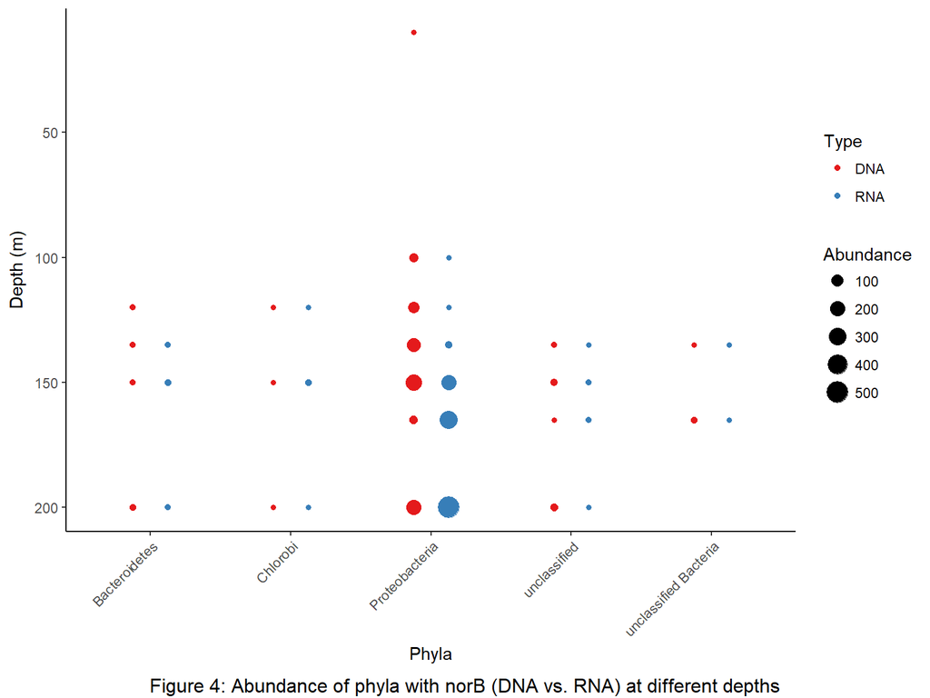

```r
plot1 <- norB.all.norm %>% # Change NAs to 'unclassified' at the level you want to plot
mutate(Phylum = ifelse(is.na(Phylum), "unclassified", Phylum)) %>% group_by(Depth_m) %>%

ggplot(aes(x = Phylum, y = Depth_m)) + # Use an ifelse statement to make 0 values into NAs so that they don't show
# up on the plot Use position_dodge to keep points from overlapping
geom_point(aes(size = ifelse(Abundance == 0, NA, Abundance), color = Type),
    position = position_dodge(0.5)) + scale_y_reverse(lim = c(200, 10)) + scale_size("Abundance") +
    labs(x = "Phyla", y = "Depth (m)") + theme_classic() + theme(axis.text.x = element_text(angle = 45,
    hjust = 1))

annotate_figure(plot1, bottom = text_grob("Figure 4: Abundance of phyla with norB (DNA vs. RNA) at different depths",
    size = 12))
```

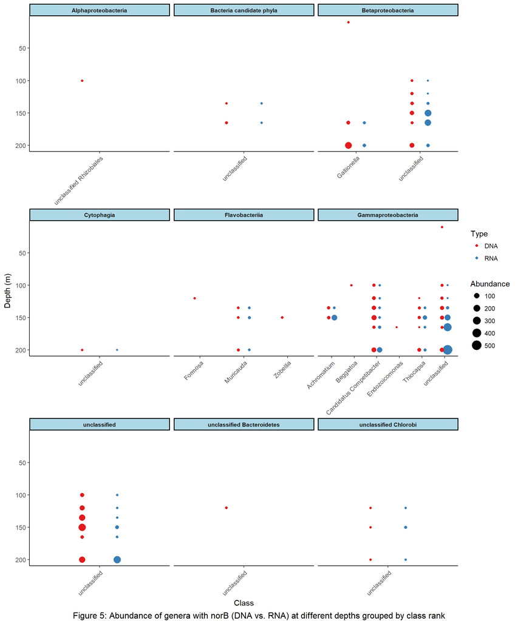

```r
plot1 <- norB.all.norm %>% # Change NAs to 'unclassified' at the level you want to plot
mutate(Genus = ifelse(is.na(Genus), "unclassified", Genus)) %>% mutate(Class = ifelse(is.na(Class),
    "unclassified", Class)) %>% ggplot(aes(x = Genus, y = Depth_m)) + # Use an ifelse statement to make 0 values into NAs so that they don't show
# up on the plot Use position_dodge to keep points from overlapping
geom_point(aes(size = ifelse(Abundance == 0, NA, Abundance), color = Type),
    position = position_dodge(0.5)) + scale_y_reverse(lim = c(200, 10)) + scale_size("Abundance") +
    labs(x = "Class", y = "Depth (m)") + theme_classic() + theme(axis.text.x = element_text(angle = 45,
    hjust = 1)) + facet_wrap(~Class, scales = "free_x", ncol = 3) + theme(strip.text = element_text(face = "bold",
    size = 8), strip.background = element_rect(fill = "lightblue", colour = "black",
    size = 1))
annotate_figure(plot1, bottom = text_grob("Figure 5: Abundance of genera with norB (DNA vs. RNA) at different depths grouped by class rank",
    size = 12))
```

## Analysis of the abundance of *norB* in relation to nitrogen species in Saanich

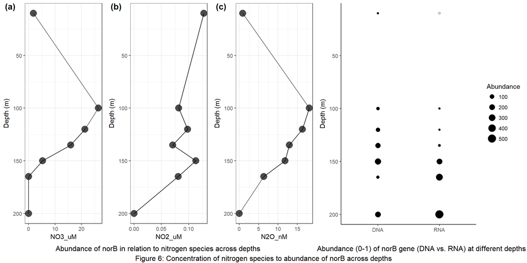

```r
load("data/mothur_phyloseq.RData")
metadata <- data.frame(mothur@sam_data)

plot2 <- metadata %>% # Order the data by depth
arrange(Depth_m) %>%
ggplot(aes(x = NO3_uM, y = Depth_m)) + geom_point(aes(x = NO3_uM, y = Depth_m),
    size = 5, alpha = 0.7) + geom_path(aes(group = 1)) + scale_y_reverse(limits = c(200,
    10)) + labs(y = "Depth (m)", x = "NO3_uM")

plot3 <- metadata %>% # Order the data by depth
arrange(Depth_m) %>%
ggplot(aes(x = NO2_uM, y = Depth_m)) + geom_point(aes(x = NO2_uM, y = Depth_m),
    size = 5, alpha = 0.7) + geom_path(aes(group = 1)) + scale_y_reverse(limits = c(200,
    10)) + labs(y = "Depth (m)", x = "NO2_uM")

plot4 <- metadata %>% # Order the data by depth
arrange(Depth_m) %>%
ggplot(aes(x = N2O_nM, y = Depth_m)) + geom_point(aes(x = N2O_nM, y = Depth_m),
    size = 5, alpha = 0.7) + geom_path(aes(group = 1)) + scale_y_reverse(limits = c(200,
    10)) + labs(y = "Depth (m)", x = "N2O_nM")

figure1 <- annotate_figure(ggarrange(plot2, plot3, plot4, ncol = 3, nrow = 1,
    labels = c("(a)", "(b)", "(c)")), bottom = text_grob("Abundance of norB in relation to nitrogen species across depths",
    size = 12))

plot1 <- norB.all.norm %>% # Change NAs to 'unclassified' at the level you want to plot
mutate(Genus = ifelse(is.na(Genus), "unclassified", Genus)) %>% group_by(Depth_m) %>%
    # Show both RNA and DNA using an x variable
ggplot(aes(x = Type, y = Depth_m)) + geom_point(aes(size = ifelse(Abundance ==
    0, NA, Abundance))) + geom_point(shape = 21) + scale_y_reverse(lim = c(200,
    10)) + # Remove zeros by setting min limit to 1e-09
scale_size("Abundance") + labs(x = "", y = "Depth (m)") + theme_classic()

figure2 <- annotate_figure(plot1, bottom = text_grob("Abundance (0-1) of norB gene (DNA vs. RNA) at different depths",
    size = 12))

annotate_figure(ggarrange(figure1, figure2, widths = c(1.5, 1)), bottom = text_grob("Figure 6: Concentration of nitrogen species to abundance of norB across depths",
    size = 12))
```

According to Fig. 6, the trend of both NO<sub>3</sub> and N<sub>2</sub>O were found to be increasing from 10m to 100m and decreasing from 100m to 200m, with levels of NO<sub>3</sub> having a more sharp decline than N<sub>2</sub>O. For the level of NO<sub>2</sub>, a sharp decline was observed from 10m to 100m, the abundance level of NO<sub>2</sub> fluctuated from 100m to 150m, and declined from 150m to 200m. *norB* is part of the denitrifying cycle that contributes to the conversion of NO into N<sub>2</sub>O. The level of *norB* was found to be present past the depth level of 100m. RNA expression level of *norB* was observed to be increasing, whereas some fluctuations were observed for the expression level of DNA.

The comparisons of the graphs in Fig. 6 indicated that the expression of *norB* was increasing from the depth of 100m to 200m. The presence of such gene has contributed to the decline in the level of NO<sub>2</sub> and NO<sub>3</sub> after 100m via the denitrifying pathway. NO<sub>2</sub> and NO<sub>3</sub> were the reactants in the denitrification reactions that were converted into NO in the nitrogen cycle. The level of N<sub>2</sub>O was expected to increase since *norB* contributed to the conversion of NO into N<sub>2</sub>O. Thus the decline in level of N<sub>2</sub>O could be attributed to the presence of other genes in the nitrogen cycle.

# Discussion

The discussion regarding denitrification in the last day of lecture revealed that at the 100m depth most genes involved in the denitrification pathway like *norB* were present, but they were neither abundant nor highly expressed. However, the *nirK*/*nirS* genes encoding nitrite reductase had high abundance and high expression, suggesting that nitrite reductase was actively being reduced to nitric oxide at this depth. The rest of the pathway had low activity by comparison, including the gene encoding the nitrate reductase subunit, *napA*, which had low abundance and low expression. At the depth of 200m, most genes involved in the denitrification pathway were also present and were expressed in high levels. This was observed especially for *norB*, which was shown to be the most abundantly expressed at depth 200m. *norC* genes were also found to have similar expression level compared with *norB* across all depth levels. One paper brought up evidence that the genes norB and norC worked as subunits in the cNOR enzyme in other nitrogen species containing nitric oxide reductase (17).

The environmental and evolutionary standpoints are interconnected in regards to the distributed metabolism seen in the nitrogen cycle. At various depths, the temperatures and presence of other chemical species will differ, with some being more significant than others. The differences in temperature and presence of other chemical species may in turn affect the entropy production (13). According to one study (13), biological systems acquire information through evolution and store it within its metagenome for maximum entropy production (MEP). Biological systems may then use this information to achieve MEP and further refine it through evolution. In other words, biological systems that can achieve MEP efficiently are able to allocate resources in expressing the optimal genes for survival in terms of their functional efficiency at the optimal temperatures and resource availability in the environment (13).

For future experiments, it would be interesting to examine the relationship between the genera associated with the *norB* gene. It is possible that the abundance of one genus can have an effect on the other at certain depths. Looking into which factors favour the growth of certain genera over the other could also be a viable project. It is worth noting that although our study was primarily concerned with the presence of one particular gene in the denitrification pathway, this method can be extended to examine other metabolic pathways in biogeochemical cycles such as decomposition.

# References

1. Hawley, AK, Torres-beltrÃ¡n, M, Zaikova, E, Walsh, DA, Mueller, A, Scofield, M, Kheirandish, S, Payne, C, Pakhomova, L, Bhatia, M, Shevchuk, O, Gies, EA, Fairley, D, Malfatti, SA, Norbeck, AD, Brewer, HM, Pasa-tolic, L, Tijana Glavina Del Rio, Suttle, CA, Tringe, S, Hallam, SJ. 2017. A compendium of multi-omic sequence information from the Saanich Inlet water column. Scientific Data. 4:170160. doi: 10.1038/sdata.2017.160.
2. Hallam, SJ, Torres-beltrÃ¡n, M, Hawley, AK. 2017. Monitoring microbial responses to ocean deoxygenation in a model oxygen minimum zone. Scientific Data. 4:170158. doi: 10.1038/sdata.2017.158.
3. Ulloa, O, Canfield, DE, DeLong, EF, Letelier, RM, Stewart, FJ. 2012. Microbial oceanography of anoxic oxygen minimum zones. Proc. Natl. Acad. Sci. U. S. A. 109:15996-16003. doi: 10.1073/pnas.1205009109.
4. Wright, JJ, Konwar, KM, Hallam, SJ. 2012. Microbial ecology of expanding oxygen minimum zones. Nature Reviews.Microbiology. 10:381. doi: 10.1038/nrmicro2778.
5. Stein LY, Klotz MG. 2016. The nitrogen cycle . Cell Press 26:R94-R98.
6. Falkowski PG, Fenchel T, Delong EF. 2008. The Microbial Engines That Drive Earth’ss Biogeochemical Cycles. Science 320:1034-1039.
7. Knowles R. 1982. Denitrification . Microbiological Reviews 46: 43-70.
8. Bergaust L, Spanning RJMV, Frostegard A, Bakken LR. 2011. Expression of nitrous oxide reductase in Paracoccus denitrificans is regulated by oxygen and nitric oxide through FnrP and NNR. Microbiology 158:826-834.
9. Dalsgaard T, Stewart FJ, Thamdrup B, Brabandere LD, Revsbech NP, Ulloa O, Canfield DE, Delong EF. 2014. Oxygen at Nanomolar Levels Reversibly Suppresses Process Rates and Gene Expression in Anammox and Denitrification in the Oxygen Minimum Zone off Northern Chile. mBio 5.
10. Qu Zhi, Bakken LR, Molstad L, Frostegard A, Bergaust LL. 2016. Transcriptional and metabolic regulation of denitrification in Paracoccus denitrificans allow low but significant activity of nitrous oxide reductase under oxic conditions. Environmental Microbiology 18: 2951-2963.
11. Louca S, Hawley AK, Katsev S, Torres-Beltran M, Bhatia MP, Kheirandish S, Michiels CC, Capelle D, Lavik G, Doebeli M, Crowe SA, Hallam SJ. 2016. Integrating biogeochemistry with multiomic sequence information in a model oxygen minimum zone. Proc Natl Acad Sci 113:E5925â“E5933.
12. Hawley AK, Brewer HM, Norbeck AD, Pa a-Toli L, Hallam SJ. 2014. Metaproteomics reveals differential modes of metabolic coupling among ubiquitous oxygen minimum zone microbes. Proc Natl Acad Sci 111:11395-11400.
13. Vallino JJ. 2010. Ecosystem biogeochemistry considered as a distributed metabolic network ordered by maximum entropy production. Philosophical Transactions: Biological Sciences. 365:1417-1427.
14. Christensen S. 1988. Oxygen control prevents denitrifiers and barley plant roots from directly competing for nitrate. FEMS Microbiology Letters. 53:217-221.
15. Morgan-Lang C and McFarland KD. TreeSAPP Demo. https://github.com/EDUCE-UBC/MICB425/blob/master/Module_04/Project2/Project2_TreeSAPP_code.html; 2018.
16. Metagenomics. http://www.metagenomics.wiki/pdf/definition/rpkm-calculation; 2018.
17. Schurig-Briccio LA, Venkatakrishnan P, Hemp J, Bricio C, Berenguer J, Gennis RB. 2013. Characterization of the nitric oxide reductase from Thermus thermophilus. Proceedings of the National Academy of Sciences of the United States of America. 110:12613-12618.
18. Fischer, H. M. (1994). Genetic regulation of nitrogen fixation in rhizobia. Microbiological reviews, 58(3), 352-386.
19. Benhizia, Y., Benhizia, H., Benguedouar, A., Muresu, R., Giacomini, A., & Squartini, A. (2004). Gamma proteobacteria can nodulate legumes of the genus Hedysarum. Systematic and applied microbiology, 27(4), 462-468.